# R Notebook

Names: Andrew McDonald and Nikolai Tverdoklheb

```r
example <- read.csv("sample_submission.csv")
head(example)
```

|  | Id | Predicted |
| --- | --- | --- |
| 1 | 0 | 1 |
| 2 | 1 | 0 |
| 3 | 2 | 0 |
| 4 | 3 | 0 |
| 5 | 4 | 0 |
| 6 | 5 | 1 |

```r
test <- read.csv("test.csv")
train <- read.csv("train.csv")

head(train)
```

|  | X0 | X1 | X2 | X3 | X4 | X5 | X6 | X7 | X8 | X9 | X10 | X11 | X12 | X13 | X14 | X15 | X16 | X17 | X18 | X19 | X20 | X21 | X22 | X23 | X24 | X25 | X26 | X27 | X28 | … |
| --- | --- | --- | --- | --- | --- | --- | --- | --- | --- | --- | --- | --- | --- | --- | --- | --- | --- | --- | --- | --- | --- | --- | --- | --- | --- | --- | --- | --- | --- | --- |
| 1 | 481 | 514 | 501 | 483 | 486 | 486 | 427 | 477 | 480 | 487 | 575 | 497 | 470 | 499 | 502 | 468 | 494 | 516 | 460 | 485 | 461 | 466 | 470 | 473 | 511 | 537 | 487 | 471 | 467 | … |
| 2 | 472 | 442 | 495 | 490 | 557 | 481 | 555 | 476 | 487 | 485 | 514 | 491 | 447 | 449 | 454 | 485 | 504 | 510 | 527 | 476 | 498 | 476 | 479 | 488 | 581 | 524 | 524 | 470 | 501 | … |
| 3 | 472 | 465 | 618 | 494 | 456 | 483 | 444 | 477 | 483 | 480 | 528 | 483 | 494 | 439 | 489 | 466 | 482 | 467 | 495 | 467 | 492 | 484 | 483 | 492 | 477 | 485 | 503 | 482 | 438 | … |
| 4 | 491 | 462 | 513 | 491 | 450 | 477 | 520 | 474 | 459 | 484 | 446 | 469 | 542 | 497 | 486 | 501 | 493 | 553 | 464 | 476 | 502 | 514 | 479 | 485 | 441 | 503 | 481 | 463 | 500 | … |
| 5 | 486 | 487 | 527 | 477 | 502 | 477 | 503 | 476 | 467 | 468 | 514 | 475 | 492 | 445 | 494 | 476 | 499 | 463 | 483 | 478 | 496 | 504 | 472 | 467 | 521 | 521 | 461 | 480 | 493 | … |
| 6 | 487 | 525 | 432 | 480 | 541 | 467 | 483 | 477 | 463 | 485 | 540 | 515 | 469 | 511 | 477 | 503 | 462 | 505 | 478 | 495 | 482 | 482 | 473 | 493 | 559 | 517 | 481 | 491 | 469 | … |

To get a better understanding of our data lets try and observe the standard deviation of a random sample of features.

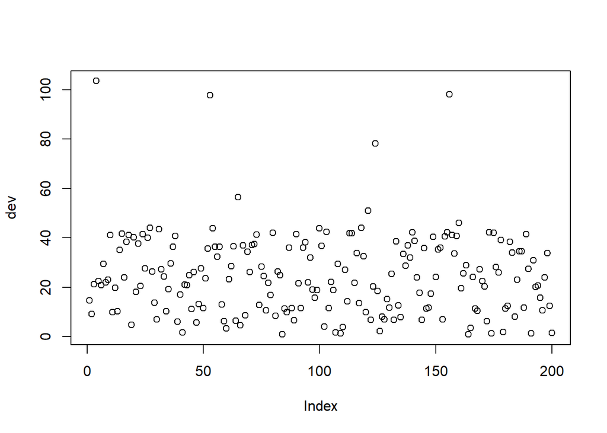

```r
dev <- c(1:200)
c <- 1
for (i in sample(1:500, 200, replace = FALSE)) {
  dev[c] <- sd(train[,c(i)])
  c = c + 1
}
plot(dev)
```

We conclude from this analysis that the standard deviation for most features is contained between 0 and 40 but a few columns go higher than this threshold we could maybe take advantage of this later.

Lets try to do the same analysis after getting rid of some extreme values.

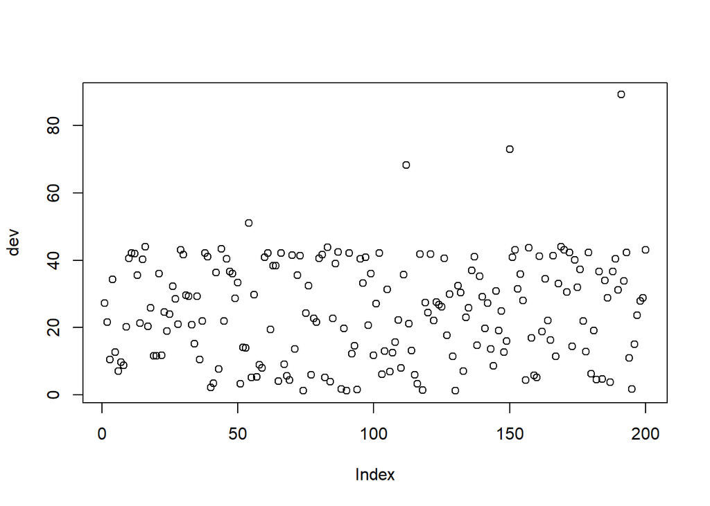

```r
x <- train
for(i in 1:500){
  moy <- mean(x[,i])
  for (j in 1:1500) {
    if (x[j, i] > 700 || x[j, i] < 300){
      x[j, i] <- moy
    }
  }
}
dev <- c(1:200)
c <- 1
for (i in sample(1:500, 200, replace = FALSE)) {
  dev[c] <- sd(x[,c(i)])
  c = c + 1
}
plot(dev)
```

There is no significant improvement in the analysis.

```r
library(MASS)
library(class)
library(nnet)
library(caret)
library(klaR)
pca <- prcomp(train, center=TRUE, scale=TRUE)
```

```r
variance = (pca$sdev)**2
inertia = variance/sum(variance)
result = cumsum(inertia)[300]
cat("Inertia captured by the first 300 principal components: ", result)
```

```
## Inertia captured by the first 300 principal components:  0.8331288
```

We can see that the data cannot be explained by a small number of variables, thus it is very difficult to actually observe the data and understand it in a simple way.

For example if we try to observe the data projected on the 2 first components of the pca we get this plot:

```r
library(devtools)
```

```r
install_github("vqv/ggbiplot")
```

[output not shown]

```
## Skipping install of 'ggbiplot' from a github remote, the SHA1 (7325e880) has not changed since last install.
##   Use `force = TRUE` to force installation
```

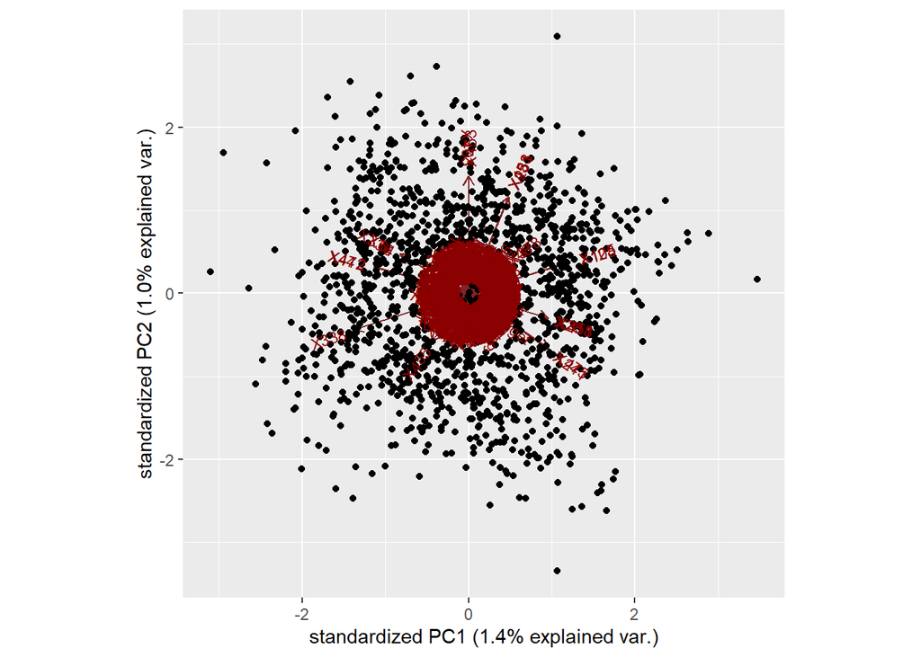

```r
library(ggbiplot)
ggbiplot(pca)
```

These 2 components explain only a few percents of the variability of the data and the plot we get is centered and apparently distributed in a pretty uniform way.

We will test different prediction methods to try and predict the data properly. To get a hint about the accuracy of our method we are going to seperate our training data into 2 groups, 20% of the data will be use for testing and getting an accuracy calculation of our models and the rest will be use for training.

We opted for this very simple method because more complicated k-cross validation has a very long runtime (as the number of observations is pretty high). Thus our prediction of the accuracy of the model may be biaised.

Also for some models we will use the 300 first pca components instead of the whole set for the training.

```r
train.tr <- train[-c(1:300),]
train.te <- train[c(1:300),]
train.pred <- train[c(1:300), c(501)]

train.pca <- as.data.frame(cbind(pca$x[,c(1:300)], as.logical(train.pred)))
train.pca.tr <- train.pca[-c(1:300),]
train.pca.te <- train.pca[c(1:300),]
train.pca.pred <- train[c(1:300), c(501)]
```

Logistic prediction:

```r
get_logistic_pred = function(model, data, pos = 1, neg = 0, cut = 0.5) {
  probs = predict(model, newdata = data)
  ifelse(probs > cut, pos, neg)
}
```

```r
glm_model <- glm(target~., data = train.tr, family = binomial("logit"))
glm_prediction <- get_logistic_pred(glm_model, train.te)
mean(glm_prediction == train.pred)
```

```
## [1] 0.5133333
```

This model gives a very bad prediction which is close to a random prediction.

Perceptron:

```r
perceptron <-nnet(target~., data = train.tr, skip =TRUE, size =0,maxit=1000)
perceptron_prediction <- predict(perceptron, train.te)

mean(perceptron_prediction == train.pred)
```

```
## [1] 0.4766667
```

The perceptron also give a precision close to random precision.

LDA:

```r
lda_model <- lda(target~., data = train.tr)
lda_prediction <- predict(lda_model, train.te)
mean(lda_prediction$class == train.pred)
```

```
## [1] 0.54
```

LDA in the whole data gives a result which is bearly better than the other ones.

LDA on the projected data:

```r
lda_model_2 <- lda(train.pca.tr[,c(301)]~., data = train.pca.tr[,-c(301)])
lda_prediction_2 <- predict(lda_model_2, train.pca.te)
mean(lda_prediction_2$class == train.pca.pred)
```

```
## [1] 0.5466667
```

With pca before lda the result is slightly better but still not very encouraging.

knn:

```r
normalize <- function(x) { (x - min(x))/(max(x) - min(x))}
```

```r
train.tr.norm <- lapply(train.tr, normalize)
knn_prediction <- knn(train.tr, train.te, train.tr[,501], k=18)
mean(knn_prediction == train.pred)
```

```
## [1] 0.7566667
```

This prediction is the best we got so far.

knn with projected data:

```r
train.pca.tr.norm <- lapply(train.pca.tr, normalize)
knn_prediction <- knn(train.pca.tr, train.pca.te,cl = train.pca.tr[,c(301)], k=300)
mean(knn_prediction == train.pred)
```

```
## [1] 0.6033333
```

Surprisingly this gives a result which is worst than for the unprojected data. A possible reason for this is that the pca we performed does not explain enough of the data to get a correct result with the knn method.